# MPDW TUGAS PRAK 1

Kezia Imanuella Victoria

2026-08-26

# Library/Packages

```r
library("forecast")
```

```r
library("graphics")
library("TTR")
library("TSA")
```

# Impor Data

```r
library(readxl)
data1 <- read_excel("C:/Users/lenovo/Downloads/mpdw 500 kezia.xlsx")

# menampilkan 5 data pertama
head(data1)
```

```
## # A tibble: 6 × 3
##   KOTA  TANGGAL    `SUHU MAX`
##   <chr> <chr>           <dbl>
## 1 Delhi 14/03/2024       29
## 2 Delhi 15/03/2024       27.0
## 3 Delhi 16/03/2024       27.1
## 4 Delhi 17/03/2024       28.1
## 5 Delhi 18/03/2024       28.0
## 6 Delhi 19/03/2024       29.1
```

```r
data1$TANGGAL <- as.Date(data1$TANGGAL, format = "%d/%m/%Y")
```

# Eksplorasi Data

```r
View(data1)
str(data1)
```

```
## tibble [146 × 3] (S3: tbl_df/tbl/data.frame)
##  $ KOTA    : chr [1:146] "Delhi" "Delhi" "Delhi" "Delhi" ...
##  $ TANGGAL : Date[1:146], format: "2024-03-14" "2024-03-15" ...
##  $ SUHU MAX: num [1:146] 29 27 27.1 28.1 28 ...
```

```r
dim(data1)
```

```
## [1] 146   3
```

Mengubah data agar terbaca sebagai data deret waktu dengan fungsi ts() .

```r
data1.ts <- ts(data1$`SUHU MAX`)
```

```r
summary(data1.ts)
```

```
##    Min. 1st Qu.  Median    Mean 3rd Qu.    Max.
##   27.04   33.09   36.07   36.90   40.08   46.04
```

Membuat plot data deret waktu

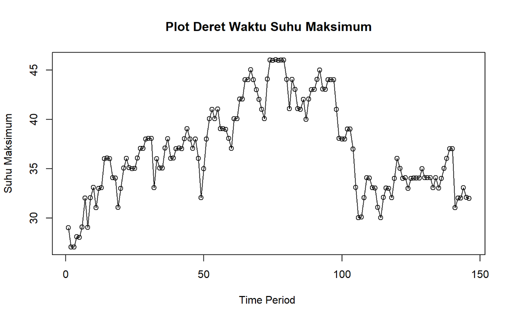

```r
ts.plot(data1.ts, xlab="Time Period ", ylab="Suhu Maksimum",
        main = "Plot Deret Waktu Suhu Maksimum")
points(data1.ts)
```

```r
#menyimpan plot
dev.copy(png, "plot_data1.png")
```

```r
dev.off()
```

# Pembagian Data

Pembagian data latih dan data uji dilakukan dengan perbandingan 80% data latih dan 20% data uji.

```r
# hitung jumlah data
n <- nrow(data1)

# tentukan batas 80%
n_train <- floor(0.8 * n)

# bagi data
training <- data1[1:n_train, ]
testing  <- data1[(n_train+1):n, ]

# ubah ke time series
train.ts <- ts(training$`SUHU MAX`)
test.ts  <- ts(testing$`SUHU MAX`)
```

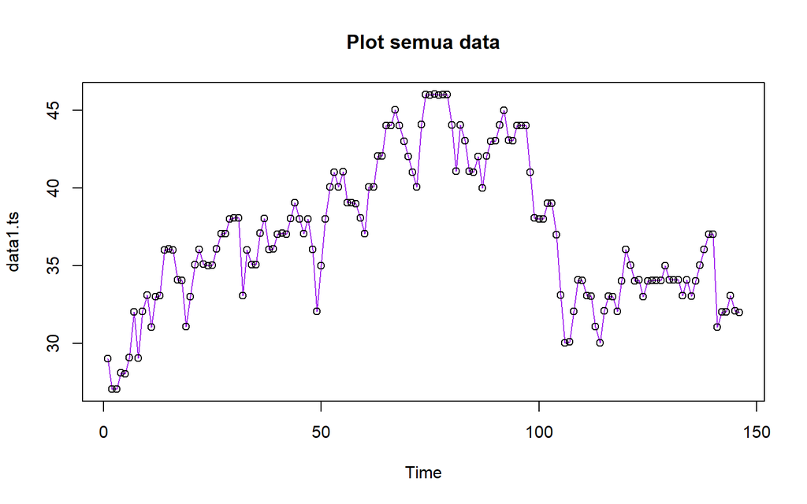

```r
#eksplorasi keseluruhan data
plot(data1.ts, col="purple",main="Plot semua data")
points(data1.ts)
```

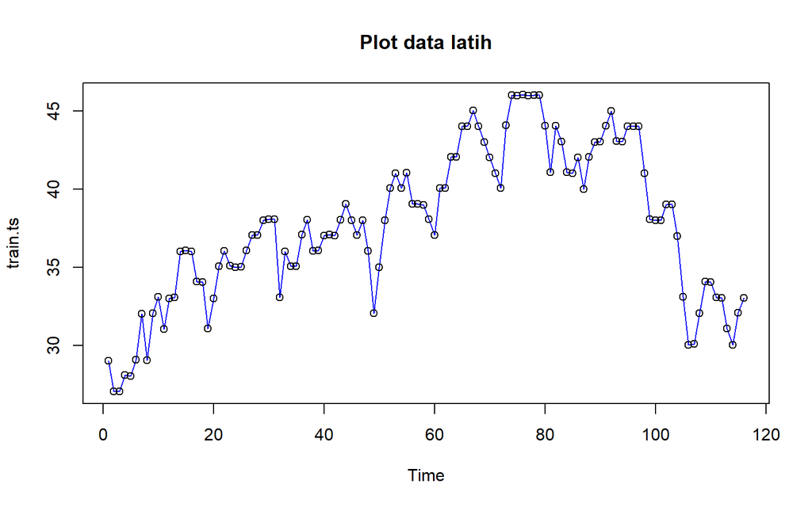

```r
#eksplorasi data latih
plot(train.ts, col="blue",main="Plot data latih")
points(train.ts)
```

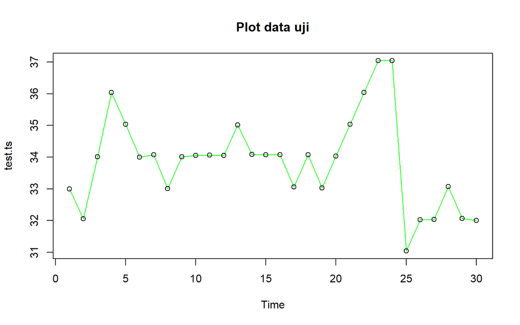

```r
#eksplorasi data uji
plot(test.ts, col="green",main="Plot data uji")
points(test.ts)
```

Eksplorasi data dilakukan menggunakan package ggplot2

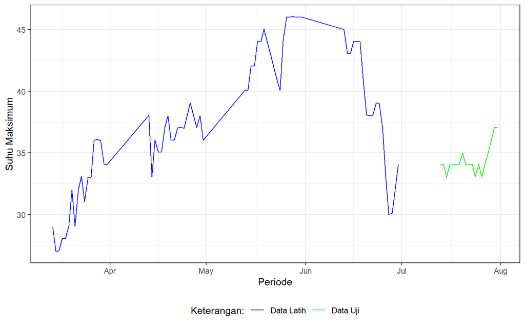

```r
library(ggplot2)
ggplot() +
  geom_line(data = training, aes(x = TANGGAL, y = `SUHU MAX`, col = "Data Latih")) +
  geom_line(data = testing, aes(x = TANGGAL, y = `SUHU MAX`, col = "Data Uji")) +
  labs(x = "Periode", y = "Suhu Maksimum", color = "Legend") +
   scale_colour_manual(name="Keterangan:", breaks = c("Data Latih", "Data Uji"),
                      values = c("blue", "green")) +
  theme_bw() + theme(legend.position = "bottom",
                     plot.caption = element_text(hjust=0.5, size=12))
```

# Single Moving Average (SMA)

## Forecasting

Pemulusan menggunakan metode SMA dengan parameter m=4

```r
data.sma<-SMA(train.ts, n=4)
data.sma
```

```
## Time Series:
## Start = 1
## End = 116
## Frequency = 1
##   [1]      NA      NA      NA 27.7950 27.5550 28.0675 29.3050 29.5450 30.5500
##  [10] 31.5500 31.3050 32.2950 32.5425 33.2750 34.5375 35.2900 35.5475 35.0550
##  [19] 33.8025 33.0500 33.2950 33.7900 34.7950 35.2975 35.2925 35.3075 35.8025
##  [28] 36.3175 37.0600 37.5525 37.8000 36.7975 36.3000 35.5525 34.8025 35.8100
##  [37] 36.3125 36.5550 36.8050 36.7875 36.5525 36.7950 37.2875 37.7925 38.0225
##  [46] 38.0350 38.0300 37.2775 35.7900 35.2775 35.2800 36.2900 38.5275 39.7925
##  [55] 40.5475 40.2950 39.8075 39.5400 38.7975 38.2950 38.5500 38.8175 39.8125
##  [64] 41.0625 42.0475 43.0375 43.7850 44.2775 44.0225 43.5200 42.5175 41.5325
##  [73] 41.8025 42.8050 44.0475 45.5375 46.0175 46.0175 46.0200 45.5225 44.2950
##  [82] 43.8050 43.0650 42.3250 42.3025 41.7950 41.0350 41.2750 41.7800 42.0325
##  [91] 43.0425 43.7825 43.7950 43.7975 43.7950 43.5525 43.7950 43.2825 41.7925
## [100] 40.2825 38.7750 38.2775 38.5125 38.2625 37.0325 34.7825 32.5500 31.3150
## [109] 31.5600 32.5700 33.3125 33.5525 32.8025 31.7900 31.5425 31.5475
```

```r
data.ramal<-c(NA,data.sma)
data.ramal #forecast 1 periode ke depan
```

```
##   [1]      NA      NA      NA      NA 27.7950 27.5550 28.0675 29.3050 29.5450
##  [10] 30.5500 31.5500 31.3050 32.2950 32.5425 33.2750 34.5375 35.2900 35.5475
##  [19] 35.0550 33.8025 33.0500 33.2950 33.7900 34.7950 35.2975 35.2925 35.3075
##  [28] 35.8025 36.3175 37.0600 37.5525 37.8000 36.7975 36.3000 35.5525 34.8025
##  [37] 35.8100 36.3125 36.5550 36.8050 36.7875 36.5525 36.7950 37.2875 37.7925
##  [46] 38.0225 38.0350 38.0300 37.2775 35.7900 35.2775 35.2800 36.2900 38.5275
##  [55] 39.7925 40.5475 40.2950 39.8075 39.5400 38.7975 38.2950 38.5500 38.8175
##  [64] 39.8125 41.0625 42.0475 43.0375 43.7850 44.2775 44.0225 43.5200 42.5175
##  [73] 41.5325 41.8025 42.8050 44.0475 45.5375 46.0175 46.0175 46.0200 45.5225
##  [82] 44.2950 43.8050 43.0650 42.3250 42.3025 41.7950 41.0350 41.2750 41.7800
##  [91] 42.0325 43.0425 43.7825 43.7950 43.7975 43.7950 43.5525 43.7950 43.2825
## [100] 41.7925 40.2825 38.7750 38.2775 38.5125 38.2625 37.0325 34.7825 32.5500
## [109] 31.3150 31.5600 32.5700 33.3125 33.5525 32.8025 31.7900 31.5425 31.5475
```

Selanjutnya dilakukan peramalan sebanyak 30 periode sesuai dengan jumlah data uji. Pada metode SMA, seluruh hasil peramalan untuk 30 periode ke depan akan memiliki nilai yang sama dengan hasil ramalan satu periode ke depan.

```r
data.gab<-cbind(
  aktual=c(data1.ts),
  pemulusan=c(data.sma,rep(NA,30)),
  ramalan=c(data.ramal,rep(data.ramal[length(data.ramal)],29)))

#forecast 30 periode ke depan
data.gab
```

```
##        aktual pemulusan ramalan
##   [1,]  29.00        NA      NA
##   [2,]  27.04        NA      NA
##   [3,]  27.06        NA      NA
##   [4,]  28.08   27.7950      NA
##   [5,]  28.04   27.5550 27.7950
##   [6,]  29.09   28.0675 27.5550
##   [7,]  32.01   29.3050 28.0675
##   [8,]  29.04   29.5450 29.3050
##   [9,]  32.06   30.5500 29.5450
##  [10,]  33.09   31.5500 30.5500
##  [11,]  31.03   31.3050 31.5500
##  [12,]  33.00   32.2950 31.3050
##  [13,]  33.05   32.5425 32.2950
##  [14,]  36.02   33.2750 32.5425
```

[output cut: 132 more lines]

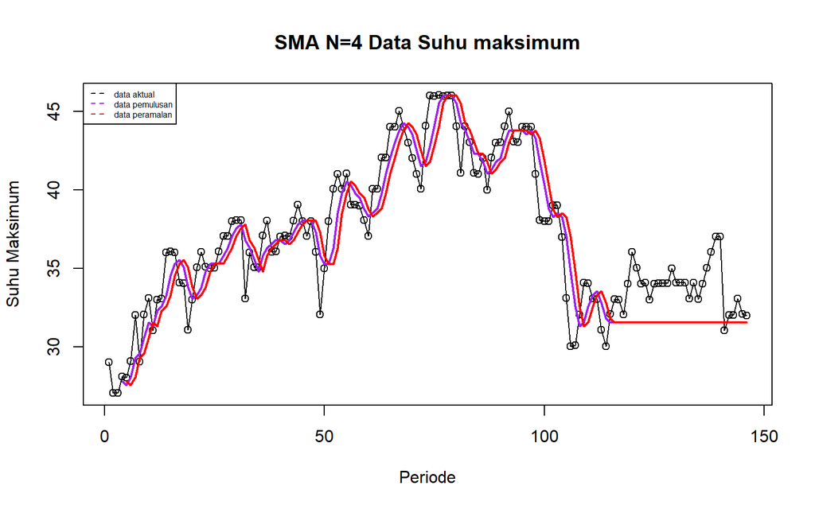

```r
ts.plot(data1.ts, xlab="Periode", ylab="Suhu Maksimum", main= "SMA N=4 Data Suhu maksimum")
points(data1.ts)
lines(data.gab[,2],col="purple",lwd=2)
lines(data.gab[,3],col="red",lwd=2)
legend("topleft",c("data aktual","data pemulusan","data peramalan"), lty=8, col=c("black","purple","red"), cex=0.5)
```

Selanjutnya perhitungan akurasi dilakukan dengan ukuran akurasi Sum Squares Error (SSE), Mean Square Error (MSE) dan Mean Absolute Percentage Error (MAPE).

## Akurasi Data Latih

```r
#Menghitung nilai keakuratan data latih
error_train.sma = train.ts-data.ramal[1:length(train.ts)]

SSE_train.sma = sum(error_train.sma[5:length(train.ts)]^2)
MSE_train.sma = mean(error_train.sma[5:length(train.ts)]^2)
MAPE_train.sma = mean(abs((error_train.sma[5:length(train.ts)]/train.ts[5:length(train.ts)])*100))

akurasi_train.sma <- matrix(c(SSE_train.sma, MSE_train.sma, MAPE_train.sma))
row.names(akurasi_train.sma)<- c("SSE", "MSE", "MAPE")
colnames(akurasi_train.sma) <- c("Akurasi m = 4")
akurasi_train.sma
```

```
##      Akurasi m = 4
## SSE     567.245625
## MSE       5.064693
## MAPE      4.760197
```

Dalam hal ini nilai MAPE data latih pada metode pemulusan SMA sekitar 4,7%, nilai ini dapat dikategorikan sebagai nilai akurasi yang sangat baik

## Akurasi Data Uji

```r
length(train.ts)
```

```
## [1] 116
```

```r
length(test.ts)
```

```
## [1] 30
```

```r
nrow(data.gab)
```

```
## [1] 146
```

```r
#Menghitung nilai keakuratan data uji
error_test.sma = test.ts-data.gab[117:146,3]

SSE_test.sma = sum(error_test.sma^2)
MSE_test.sma = mean(error_test.sma^2)
MAPE_test.sma = mean(abs((error_test.sma/test.ts*100)))

akurasi_test.sma <- matrix(c(SSE_test.sma, MSE_test.sma, MAPE_test.sma))
row.names(akurasi_test.sma)<- c("SSE", "MSE", "MAPE")
colnames(akurasi_test.sma) <- c("Akurasi m = 4")
akurasi_test.sma
```

```
##      Akurasi m = 4
## SSE     224.801437
## MSE       7.493381
## MAPE      6.813015
```

Perhitungan akurasi menggunakan data uji menghasilkan nilai MAPE sebesar 6.81%. Berdasarkan kriteria MAPE, nilai tersebut berada pada rentang <10%, sehingga metode peramalan dapat dikategorikan memiliki akurasi yang sangat baik.

# Double Moving Average (DMA)

## Forecasting

Dilakukan peramalan untuk 30 periode kedepan menggunakan metode DMA

```r
dma <- SMA(data.sma, n = 4)
At <- 2*data.sma - dma
Bt <- 2/(4-1)*(data.sma - dma)
data.dma<- At+Bt
data.ramal2<- c(NA, data.dma)

t = 1:30
f = c()

for (i in t) {
  f[i] = At[length(At)] + Bt[length(Bt)]*(i)
}

data.gab2 <- cbind(aktual = c(data1.ts),
                   pemulusan1 = c(data.sma,rep(NA,30)),
                   pemulusan2 = c(dma, rep(NA,30)),
                   At = c(At, rep(NA,30)),
                   Bt = c(Bt,rep(NA,30)),
                   ramalan = c(data.ramal2, f[-1]))
data.gab2
```

```
##        aktual pemulusan1 pemulusan2       At           Bt  ramalan
##   [1,]  29.00         NA         NA       NA           NA       NA
##   [2,]  27.04         NA         NA       NA           NA       NA
##   [3,]  27.06         NA         NA       NA           NA       NA
##   [4,]  28.08    27.7950         NA       NA           NA       NA
##   [5,]  28.04    27.5550         NA       NA           NA       NA
##   [6,]  29.09    28.0675         NA       NA           NA       NA
##   [7,]  32.01    29.3050   28.18062 30.42938  0.749583333       NA
##   [8,]  29.04    29.5450   28.61812 30.47188  0.617916667 31.17896
##   [9,]  32.06    30.5500   29.36687 31.73313  0.788750000 31.08979
##  [10,]  33.09    31.5500   30.23750 32.86250  0.875000000 32.52188
##  [11,]  31.03    31.3050   30.73750 31.87250  0.378333333 33.73750
##  [12,]  33.00    32.2950   31.42500 33.16500  0.580000000 32.25083
##  [13,]  33.05    32.5425   31.92312 33.16188  0.412916667 33.74500
##  [14,]  36.02    33.2750   32.35437 34.19563  0.613750000 33.57479
```

[output cut: 132 more lines]

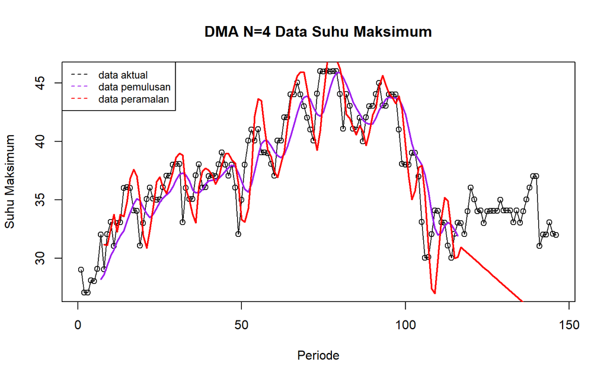

```r
ts.plot(data1.ts, xlab="Periode", ylab="Suhu Maksimum", main= "DMA N=4 Data Suhu Maksimum")
points(data1.ts)
lines(data.gab2[,3],col="purple",lwd=2)
lines(data.gab2[,6],col="red",lwd=2)
legend("topleft",c("data aktual","data pemulusan","data peramalan"), lty=8, col=c("black","purple","red"), cex=0.8)
```

Selanjutnya perhitungan akurasi dilakukan baik pada data latih maupun data uji. Perhitungan akurasi dilakukan dengan ukuran akurasi SSE, MSE dan MAPE.

## Akurasi Data Latih

```r
#Menghitung nilai keakuratan data latih
error_train.dma = train.ts-data.ramal2[1:length(train.ts)]

SSE_train.dma = sum(error_train.dma[8:length(train.ts)]^2)
MSE_train.dma = mean(error_train.dma[8:length(train.ts)]^2)
MAPE_train.dma = mean(abs((error_train.dma[8:length(train.ts)]/train.ts[8:length(train.ts)])*100))

akurasi_train.dma <- matrix(c(SSE_train.dma, MSE_train.dma, MAPE_train.dma))
row.names(akurasi_train.dma)<- c("SSE", "MSE", "MAPE")
colnames(akurasi_train.dma) <- c("Akurasi m = 4")
akurasi_train.dma
```

```
##      Akurasi m = 4
## SSE     706.512830
## MSE       6.481769
## MAPE      5.423997
```

Perhitungan akurasi pada data latih menggunakan nilai MAPE menghasilkan nilai MAPE yang kurang dari 10% sehingga dikategorikan sangat baik. Selanjutnya, perhitungan nilai akurasi dilakukan pada data uji.

## Akurasi Data Uji

```r
#Menghitung nilai keakuratan data uji
error_test.dma = test.ts-data.gab2[117:146,6]
SSE_test.dma = sum(error_test.dma^2)
MSE_test.dma = mean(error_test.dma^2)
MAPE_test.dma = mean(abs((error_test.dma/test.ts*100)))

akurasi_test.dma <- matrix(c(SSE_test.dma, MSE_test.dma, MAPE_test.dma))
row.names(akurasi_test.dma)<- c("SSE", "MSE", "MAPE")
colnames(akurasi_test.dma) <- c("Akurasi m = 4")
akurasi_test.dma
```

```
##      Akurasi m = 4
## SSE     1458.24526
## MSE       48.60818
## MAPE      19.26411
```

Perhitungan akurasi menggunakan data uji menghasilkan nilai MAPE sebesar 19.2%, Berdasarkan kriteria MAPE, nilai tersebut berada pada rentang 10%–20%, sehingga metode peramalan dapat dikategorikan memiliki akurasi yang baik.

Pada data latih dan data uji, metode SMA lebih baik dibandingkan dengan metode DMA.

# Single Exponential Smoothing

## Forecasting dengan Fungsi ses

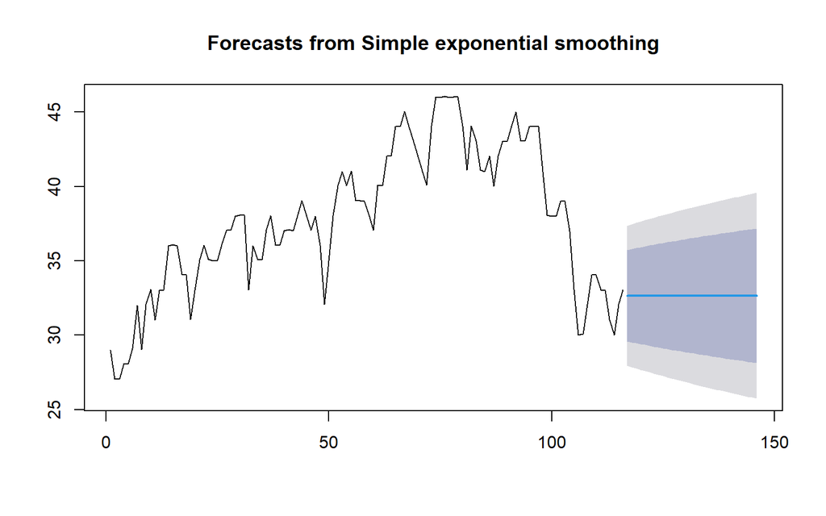

```r
#Cara 1 (fungsi ses)
ses.1 <- ses(train.ts, h = 30, alpha = 0.2)
plot(ses.1)
```

```r
ses.1
```

```
##     Point Forecast    Lo 80    Hi 80    Lo 95    Hi 95
## 117       32.65468 29.57682 35.73254 27.94750 37.36186
## 118       32.65468 29.51587 35.79350 27.85428 37.45509
## 119       32.65468 29.45608 35.85329 27.76284 37.54653
## 120       32.65468 29.39738 35.91198 27.67307 37.63630
## 121       32.65468 29.33973 35.96964 27.58490 37.72447
## 122       32.65468 29.28306 36.02631 27.49823 37.81114
## 123       32.65468 29.22732 36.08204 27.41299 37.89638
## 124       32.65468 29.17248 36.13689 27.32912 37.98025
## 125       32.65468 29.11849 36.19088 27.24655 38.06282
## 126       32.65468 29.06531 36.24405 27.16522 38.14415
## 127       32.65468 29.01291 36.29646 27.08507 38.22430
## 128       32.65468 28.96125 36.34812 27.00607 38.30330
## 129       32.65468 28.91031 36.39906 26.92815 38.38122
## 130       32.65468 28.86004 36.44932 26.85128 38.45809
```

[output cut: 16 more lines]

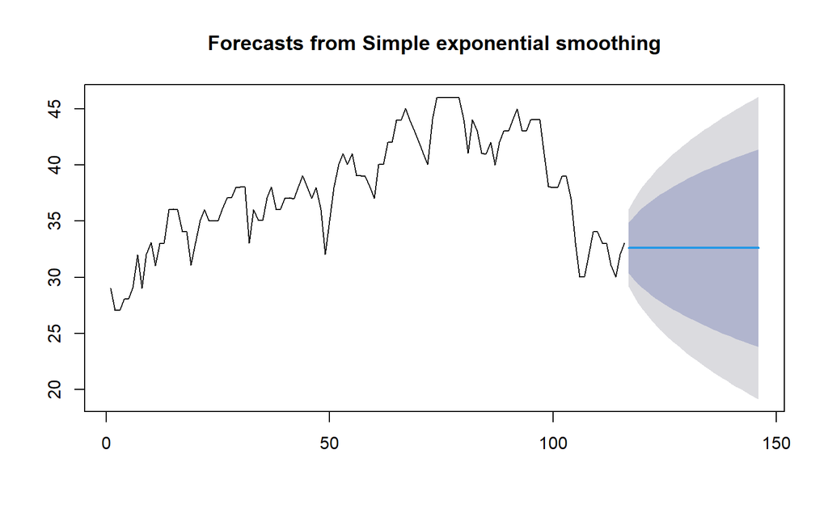

```r
ses.2<- ses(train.ts, h = 30, alpha = 0.7)
plot(ses.2)
```

```r
ses.2
```

```
##     Point Forecast    Lo 80    Hi 80    Lo 95    Hi 95
## 117       32.60868 30.34751 34.86985 29.15052 36.06685
## 118       32.60868 29.84857 35.36879 28.38745 36.82991
## 119       32.60868 29.42693 35.79043 27.74261 37.47475
## 120       32.60868 29.05497 36.16239 27.17375 38.04361
## 121       32.60868 28.71841 36.49895 26.65903 38.55833
## 122       32.60868 28.40874 36.80862 26.18542 39.03194
## 123       32.60868 28.12038 37.09698 25.74442 39.47294
## 124       32.60868 27.84946 37.36790 25.33009 39.88728
## 125       32.60868 27.59316 37.62420 24.93810 40.27926
## 126       32.60868 27.34933 37.86803 24.56519 40.65217
## 127       32.60868 27.11631 38.10105 24.20883 41.00853
## 128       32.60868 26.89279 38.32457 23.86698 41.35038
## 129       32.60868 26.67768 38.53968 23.53800 41.67936
## 130       32.60868 26.47011 38.74725 23.22054 41.99682
```

[output cut: 16 more lines]

Untuk mendapatkan gambar hasil pemulusan pada data latih dengan fungsi ses() , digunakan fungsi autoplot() dan autolayer() dari library packages ggplot2 .

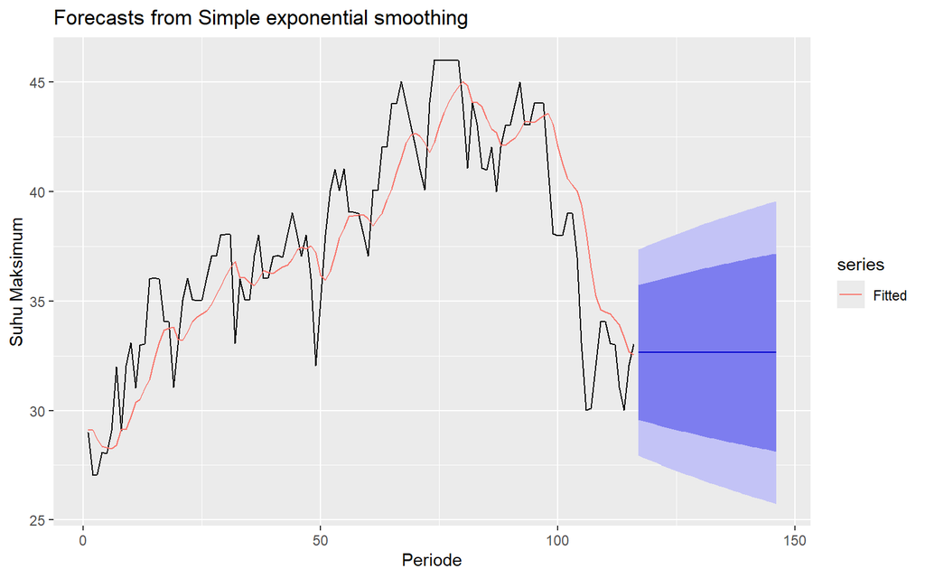

```r
autoplot(ses.1) +
  autolayer(fitted(ses.1), series="Fitted") +
  ylab("Suhu Maksimum") + xlab("Periode")
```

## Forecasting dengan Fungsi Holtwinters

Selanjutnya akan digunakan fungsi HoltWinters() dengan nilai inisialisasi parameter dan panjang periode peramalan yang sama dengan fungsi ses() .

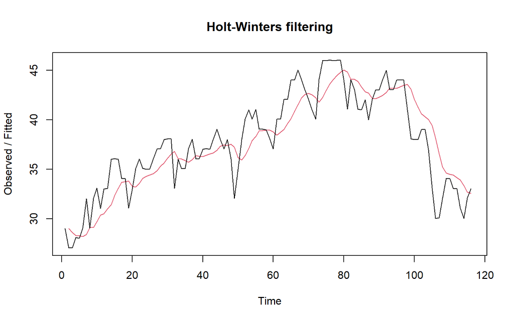

```r
#Cara 2 (fungsi Holtwinter)
ses1<- HoltWinters(train.ts, gamma = FALSE, beta = FALSE, alpha = 0.2)
plot(ses1)
```

```r
#ramalan
ramalan1<- forecast(ses1, h=30)
ramalan1
```

```
##     Point Forecast    Lo 80    Hi 80    Lo 95    Hi 95
## 117       32.65468 29.58348 35.72588 27.95769 37.35168
## 118       32.65468 29.52266 35.78671 27.86467 37.44470
## 119       32.65468 29.46300 35.84637 27.77342 37.53594
## 120       32.65468 29.40443 35.90494 27.68385 37.62552
## 121       32.65468 29.34690 35.96247 27.59587 37.71350
## 122       32.65468 29.29035 36.01902 27.50938 37.79998
## 123       32.65468 29.23474 36.07463 27.42433 37.88504
## 124       32.65468 29.18002 36.12935 27.34064 37.96873
## 125       32.65468 29.12614 36.18322 27.25825 38.05112
## 126       32.65468 29.07308 36.23629 27.17709 38.13227
## 127       32.65468 29.02079 36.28858 27.09712 38.21224
## 128       32.65468 28.96924 36.34012 27.01829 38.29108
## 129       32.65468 28.91841 36.39096 26.94054 38.36882
## 130       32.65468 28.86825 36.44111 26.86384 38.44553
```

[output cut: 16 more lines]

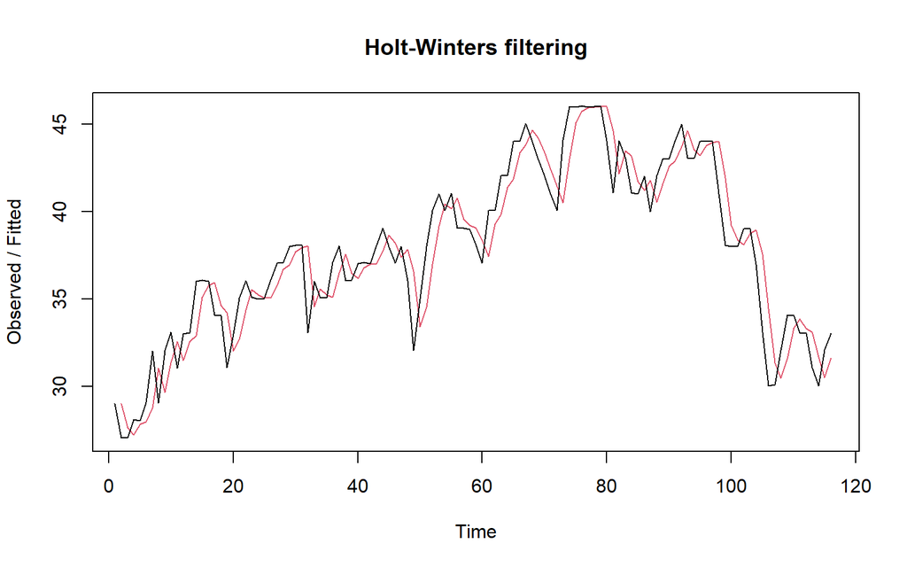

```r
ses2<- HoltWinters(train.ts, gamma = FALSE, beta = FALSE, alpha = 0.7)
plot(ses2)
```

```r
#ramalan
ramalan2<- forecast(ses2, h=30)
ramalan2
```

```
##     Point Forecast    Lo 80    Hi 80    Lo 95    Hi 95
## 117       32.60868 30.34717 34.87019 29.14999 36.06737
## 118       32.60868 29.84815 35.36921 28.38682 36.83055
## 119       32.60868 29.42645 35.79091 27.74188 37.47548
## 120       32.60868 29.05443 36.16293 27.17293 38.04443
## 121       32.60868 28.71783 36.49954 26.65813 38.55923
## 122       32.60868 28.40811 36.80926 26.18446 39.03291
## 123       32.60868 28.11970 37.09766 25.74338 39.47398
## 124       32.60868 27.84874 37.36862 25.32899 39.88837
## 125       32.60868 27.59240 37.62496 24.93694 40.28042
## 126       32.60868 27.34853 37.86883 24.56398 40.65338
## 127       32.60868 27.11548 38.10188 24.20756 41.00980
## 128       32.60868 26.89192 38.32544 23.86566 41.35170
## 129       32.60868 26.67679 38.54057 23.53663 41.68073
## 130       32.60868 26.46918 38.74818 23.21913 41.99823
```

[output cut: 16 more lines]

Nilai parameter α dari kedua fungsi dapat dioptimalkan menyesuaikan dari error-nya paling minimumnya. Caranya adalah dengan membuat parameter α= NULL.

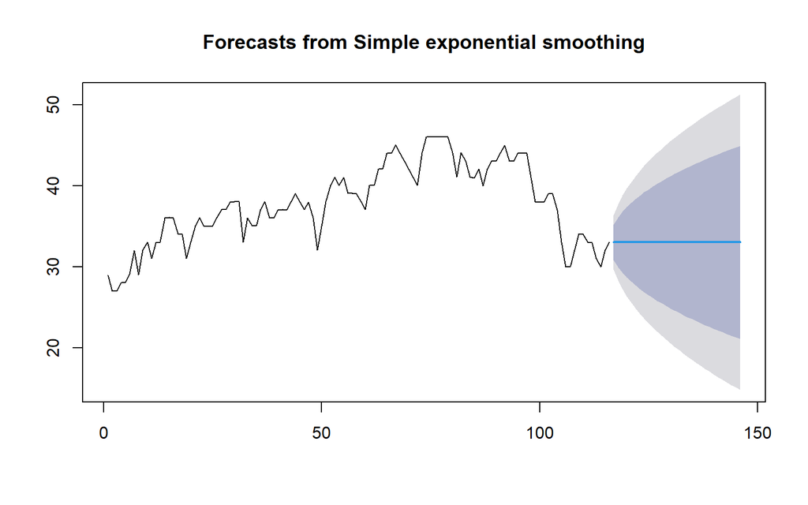

```r
#SES
ses.opt <- ses(train.ts, h = 30, alpha = NULL)
plot(ses.opt)
```

```r
ses.opt
```

```
##     Point Forecast    Lo 80    Hi 80    Lo 95    Hi 95
## 117        33.0399 30.86549 35.21432 29.71442 36.36538
## 118        33.0399 29.96497 36.11483 28.33720 37.74260
## 119        33.0399 29.27396 36.80584 27.28039 38.79941
## 120        33.0399 28.69140 37.38840 26.38945 39.69035
## 121        33.0399 28.17816 37.90164 25.60451 40.47530
## 122        33.0399 27.71415 38.36566 24.89486 41.18494
## 123        33.0399 27.28744 38.79236 24.24228 41.83753
## 124        33.0399 26.89028 39.18953 23.63486 42.44494
## 125        33.0399 26.51725 39.56256 23.06436 43.01544
## 126        33.0399 26.16443 39.91538 22.52477 43.55503
## 127        33.0399 25.82885 40.25095 22.01155 44.06825
## 128        33.0399 25.50821 40.57159 21.52117 44.55863
## 129        33.0399 25.20067 40.87913 21.05084 45.02897
## 130        33.0399 24.90476 41.17505 20.59827 45.48153
```

[output cut: 16 more lines]

```r
#Lamda Optimum Holt Winter
HWopt<- HoltWinters(train.ts, gamma = FALSE, beta = FALSE,alpha = NULL)
HWopt
```

```
## Holt-Winters exponential smoothing without trend and without seasonal component.
##
## Call:
## HoltWinters(x = train.ts, alpha = NULL, beta = FALSE, gamma = FALSE)
##
## Smoothing parameters:
##  alpha: 0.999955
##  beta : FALSE
##  gamma: FALSE
##
## Coefficients:
##       [,1]
## a 33.03996
```

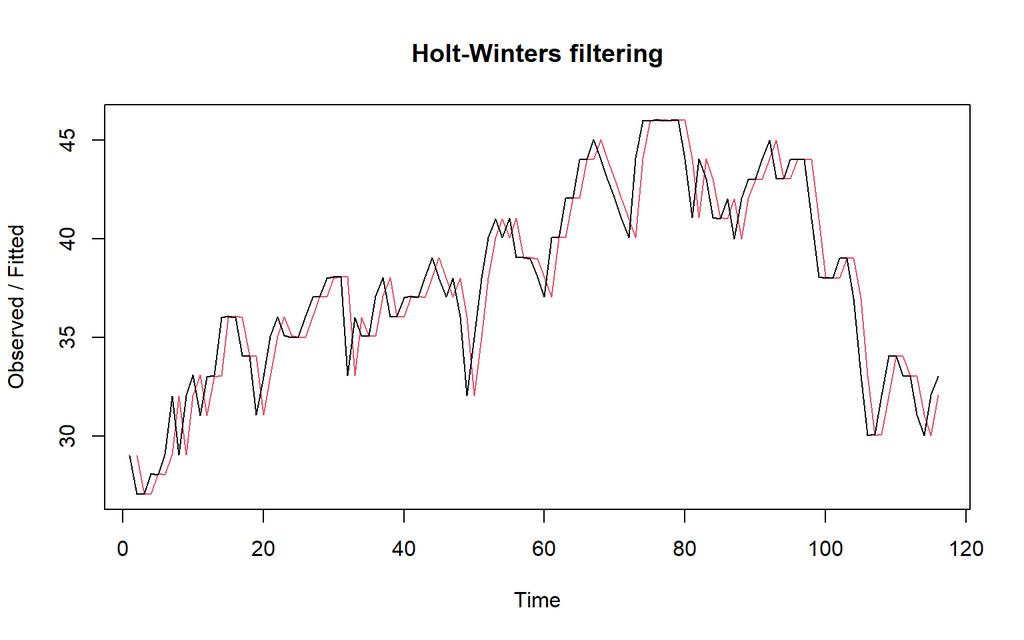

```r
plot(HWopt)
```

```r
#ramalan
ramalanopt<- forecast(HWopt, h=30)
ramalanopt
```

```
##     Point Forecast    Lo 80    Hi 80    Lo 95    Hi 95
## 117       33.03996 30.86601 35.21390 29.71520 36.36471
## 118       33.03996 29.96561 36.11430 28.33815 37.74177
## 119       33.03996 29.27469 36.80522 27.28148 38.79843
## 120       33.03996 28.69222 37.38769 26.39067 39.68925
## 121       33.03996 28.17905 37.90086 25.60584 40.47407
## 122       33.03996 27.71511 38.36480 24.89630 41.18361
## 123       33.03996 27.28847 38.79144 24.24382 41.83610
## 124       33.03996 26.89136 39.18855 23.63649 42.44342
## 125       33.03996 26.51839 39.56152 23.06609 43.01383
## 126       33.03996 26.16563 39.91428 22.52658 43.55333
## 127       33.03996 25.83010 40.24981 22.01344 44.06648
## 128       33.03996 25.50951 40.57040 21.52314 44.55678
## 129       33.03996 25.20202 40.87789 21.05287 45.02704
## 130       33.03996 24.90615 41.17376 20.60038 45.47954
```

[output cut: 16 more lines]

## Akurasi Data Latih

```r
#Keakuratan Metode
#Pada data training

# SES dengan alpha = 0.2
SSE1<-ses1$SSE
MSE1<-ses1$SSE/length(train.ts)
RMSE1<-sqrt(MSE1)

akurasi1 <- matrix(c(SSE1,MSE1,RMSE1))
row.names(akurasi1)<- c("SSE", "MSE", "RMSE")
colnames(akurasi1) <- c("Akurasi lamda=0.2")
akurasi1
```

```
##      Akurasi lamda=0.2
## SSE         657.613421
## MSE           5.669081
## RMSE          2.380983
```

```r
# SES dengan alpha = 0.7
SSE2<-ses2$SSE
MSE2<-ses2$SSE/length(train.ts)
RMSE2<-sqrt(MSE2)

akurasi2 <- matrix(c(SSE2,MSE2,RMSE2))
row.names(akurasi2)<- c("SSE", "MSE", "RMSE")
colnames(akurasi2) <- c("Akurasi lamda=0.7")
akurasi2
```

```
##      Akurasi lamda=0.7
## SSE         355.233326
## MSE           3.062356
## RMSE          1.749959
```

```r
#Cara Manual
# Alpha = 0.2
sisaan1<-ramalan1$residuals
head(sisaan1)
```

```
## Time Series:
## Start = 1
## End = 6
## Frequency = 1
## [1]        NA -1.960000 -1.548000 -0.218400 -0.214720  0.878224
```

```r
SSE.1=sum(sisaan1[2:length(train.ts)]^2)
SSE.1
```

```
## [1] 657.6134
```

```r
MSE.1 = SSE.1/length(train.ts)
MSE.1
```

```
## [1] 5.669081
```

```r
MAPE.1 = sum(abs(sisaan1[2:length(train.ts)]/train.ts[2:length(train.ts)])*
               100)/length(train.ts)
MAPE.1
```

```
## [1] 5.040584
```

```r
akurasi.1 <- matrix(c(SSE.1,MSE.1,MAPE.1))
row.names(akurasi.1)<- c("SSE", "MSE", "MAPE")
colnames(akurasi.1) <- c("Akurasi lamda=0.2")
akurasi.1
```

```
##      Akurasi lamda=0.2
## SSE         657.613421
## MSE           5.669081
## MAPE          5.040584
```

```r
# Alpha = 0.7
sisaan2<-ramalan2$residuals
head(sisaan2)
```

```
## Time Series:
## Start = 1
## End = 6
## Frequency = 1
## [1]        NA -1.960000 -0.568000  0.849600  0.214880  1.114464
```

```r
SSE.2=sum(sisaan2[2:length(train.ts)]^2)
SSE.2
```

```
## [1] 355.2333
```

```r
MSE.2 = SSE.2/length(train.ts)
MSE.2
```

```
## [1] 3.062356
```

```r
MAPE.2 = sum(abs(sisaan2[2:length(train.ts)]/train.ts[2:length(train.ts)])*
               100)/length(train.ts)
MAPE.2
```

```
## [1] 3.767861
```

```r
akurasi.2 <- matrix(c(SSE.2,MSE.2,MAPE.2))
row.names(akurasi.2)<- c("SSE", "MSE", "MAPE")
colnames(akurasi.2) <- c("Akurasi lamda=0.7")
akurasi.2
```

```
##      Akurasi lamda=0.7
## SSE         355.233326
## MSE           3.062356
## MAPE          3.767861
```

Berdasarkan nilai SSE, MSE, RMSE, dan MAPE di antara kedua parameter, nilai parameter λ=0,7 menghasilkan akurasi yang lebih baik dibanding λ=0,2

## Akurasi Data Uji

```r
# jumlah observasi uji
n_test <- nrow(testing)

# error (ramalan - aktual), samakan panjang dan tipe numeric
e1   <- as.numeric(ramalan1$mean)[1:n_test] - as.numeric(testing$`SUHU MAX`)
e2   <- as.numeric(ramalan2$mean)[1:n_test] - as.numeric(testing$`SUHU MAX`)
eopt <- as.numeric(ramalanopt$mean)[1:n_test] - as.numeric(testing$`SUHU MAX`)

# SSE / MSE / RMSE untuk masing-masing model (abaikan NA)
SSEtesting1  <- sum(e1^2,  na.rm = TRUE)
MSEtesting1  <- mean(e1^2, na.rm = TRUE)
RMSEtesting1 <- sqrt(MSEtesting1)

SSEtesting2  <- sum(e2^2,  na.rm = TRUE)
MSEtesting2  <- mean(e2^2, na.rm = TRUE)
RMSEtesting2 <- sqrt(MSEtesting2)

SSEtestingopt  <- sum(eopt^2,  na.rm = TRUE)
MSEtestingopt  <- mean(eopt^2, na.rm = TRUE)
RMSEtestingopt <- sqrt(MSEtestingopt)

# Tabel ringkas
akurasitesting_SSE <- matrix(c(SSEtesting1, SSEtesting2, SSEtestingopt),
                             nrow = 3,
                             dimnames = list(c("SSE1","SSE2","SSEopt"), "Nilai"))
akurasitesting_MSE <- matrix(c(MSEtesting1, MSEtesting2, MSEtestingopt),
                             nrow = 3,
                             dimnames = list(c("MSE1","MSE2","MSEopt"), "Nilai"))
akurasitesting_RMSE <- matrix(c(RMSEtesting1, RMSEtesting2, RMSEtestingopt),
                              nrow = 3,
                              dimnames = list(c("RMSE1","RMSE2","RMSEopt"), "Nilai"))

akurasitesting_SSE
```

```
##            Nilai
## SSE1   106.95887
## SSE2   110.39073
## SSEopt  83.20269
```

```r
akurasitesting_MSE
```

```
##           Nilai
## MSE1   3.565296
## MSE2   3.679691
## MSEopt 2.773423
```

```r
akurasitesting_RMSE
```

```
##            Nilai
## RMSE1   1.888199
## RMSE2   1.918252
## RMSEopt 1.665360
```

Kita juga dapat menggunakan fungsi accuracy() dari package forecast.

```r
accuracy(ramalan1, testing$`SUHU MAX`)
```

```
##                     ME     RMSE      MAE       MPE     MAPE     MASE      ACF1
## Training set 0.1588993 2.391313 1.868925 0.1248282 5.084415 1.490474 0.7112814
## Test set     1.2203158 1.888199 1.534189 3.4297203 4.420277 1.223521        NA
```

```r
accuracy(ramalan2, testing$`SUHU MAX`)
```

```
##                      ME     RMSE      MAE         MPE     MAPE     MASE
## Training set 0.04482832 1.757551 1.384445 -0.00976375 3.800625 1.104099
## Test set     1.26631985 1.918252 1.561792  3.56576882 4.498578 1.245534
##                   ACF1
## Training set 0.2754986
## Test set            NA
```

```r
accuracy(ramalanopt, testing$`SUHU MAX`)
```

```
##                      ME    RMSE      MAE         MPE     MAPE     MASE
## Training set 0.03513164 1.68931 1.253921 0.001511278 3.456047 1.000006
## Test set     0.83504366 1.66536 1.308351 2.290348045 3.780658 1.043414
##                    ACF1
## Training set 0.01174888
## Test set             NA
```

# Double Exponential Smoothing (DES)

## Forecasting dengan Fungsi Holtwinters

Pemulusan dengan metode DES kali ini akan menggunakan fungsi HoltWinters() . Jika sebelumnya nilai argumen beta dibuat FALSE , kali ini argumen tersebut akan diinisialisasi bersamaan dengan nilai alpha .

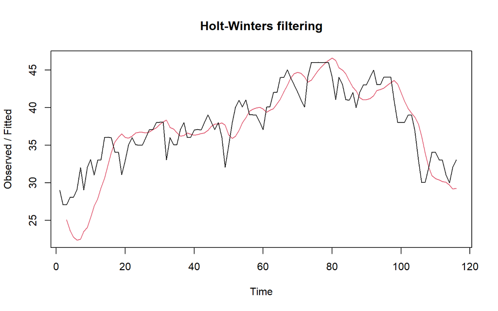

```r
#Lamda=0.2 dan gamma=0.2
des.1<- HoltWinters(train.ts, gamma = FALSE, beta = 0.2, alpha = 0.2)
plot(des.1)
```

```r
#ramalan
ramalandes1<- forecast(des.1, h=30)
ramalandes1
```

```
##     Point Forecast     Lo 80    Hi 80      Lo 95    Hi 95
## 117       29.69669 25.886338 33.50703 23.8692621 35.52411
## 118       29.37210 25.453555 33.29065 23.3791999 35.36501
## 119       29.04752 24.986328 33.10872 22.8364613 35.25858
## 120       28.72294 24.482655 32.96323 22.2379833 35.20790
## 121       28.39836 23.941717 32.85500 21.5825138 35.21420
## 122       28.07378 23.363718 32.78383 20.8703635 35.27719
## 123       27.74919 22.749646 32.74874 20.1030454 35.39534
## 124       27.42461 22.101023 32.74820 19.2828854 35.56634
## 125       27.10003 21.419672 32.78039 18.4126720 35.78739
## 126       26.77545 20.707537 32.84336 17.4953785 36.05552
## 127       26.45087 19.966554 32.93518 16.5339672 36.36777
## 128       26.12628 19.198573 33.05400 15.5312647 36.72130
## 129       25.80170 18.405308 33.19810 14.4898933 37.11351
## 130       25.47712 17.588320 33.36592 13.4122415 37.54200
```

[output cut: 16 more lines]

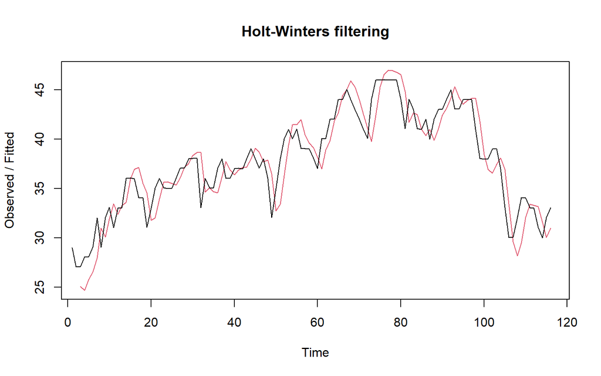

```r
#Lamda=0.6 dan gamma=0.3
des.2<- HoltWinters(train.ts, gamma = FALSE, beta = 0.3, alpha = 0.6)
plot(des.2)
```

```r
#ramalan
ramalandes2<- forecast(des.2, h=30)
ramalandes2
```

```
##     Point Forecast       Lo 80    Hi 80      Lo 95     Hi 95
## 117       32.34757  29.7132360 34.98190  28.318705  36.37643
## 118       32.46786  29.1269333 35.80880  27.358351  37.57738
## 119       32.58816  28.3979995 36.77832  26.179862  38.99646
## 120       32.70846  27.5532374 37.86368  24.824229  40.59269
## 121       32.82875  26.6103912 39.04712  23.318589  42.33892
## 122       32.94905  25.5813933 40.31671  21.681191  44.21691
## 123       33.06935  24.4746396 41.66405  19.924876  46.21382
## 124       33.18964  23.2963327 43.08295  18.059130  48.32016
## 125       33.30994  22.0512600 44.56862  16.091275  50.52860
## 126       33.43024  20.7432543 46.11722  14.027172  52.83330
## 127       33.55053  19.3754768 47.72559  11.871655  55.22941
## 128       33.67083  17.9505983 49.39106   9.628811  57.71285
## 129       33.79113  16.4709191 51.11133   7.302156  60.28010
## 130       33.91142  14.9384522 52.88439   4.894769  62.92808
```

[output cut: 16 more lines]

### Perbandingan plot data latih dan data uji

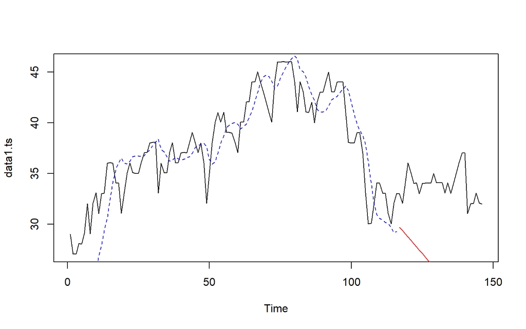

```r
plot(data1.ts)
lines(des.1$fitted[,1], lty=2, col="blue")
lines(ramalandes1$mean, col="red")
```

Untuk mendapatkan nilai parameter optimum dari DES, argumen alpha dan beta dapat dibuat NULL seperti berikut.

```r
#Lamda dan gamma optimum
des.opt<- HoltWinters(train.ts, gamma = FALSE)
des.opt
```

```
## Holt-Winters exponential smoothing with trend and without seasonal component.
##
## Call:
## HoltWinters(x = train.ts, gamma = FALSE)
##
## Smoothing parameters:
##  alpha: 1
##  beta : 0.09933411
##  gamma: FALSE
##
## Coefficients:
##         [,1]
## a 33.0400000
## b -0.1735189
```

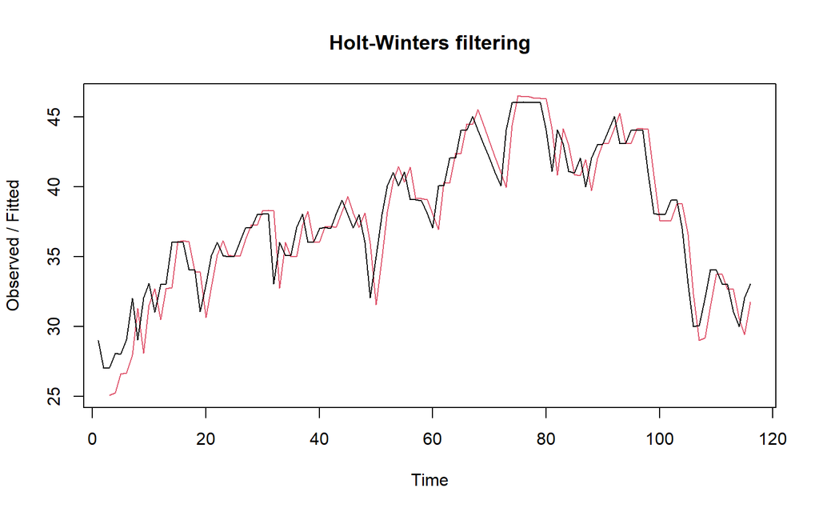

```r
plot(des.opt)
```

```r
#ramalan
ramalandesopt<- forecast(des.opt, h=30)
ramalandesopt
```

```
##     Point Forecast      Lo 80    Hi 80       Lo 95    Hi 95
## 117       32.86648 30.5352795 35.19768  29.3012159 36.43175
## 118       32.69296 29.2285303 36.15739  27.3945708 37.99135
## 119       32.51944 28.0685323 36.97035  25.7123622 39.32652
## 120       32.34592 26.9638513 37.72800  24.1147539 40.57710
## 121       32.17241 25.8813133 38.46350  22.5510102 41.79380
## 122       31.99889 24.8050527 39.19272  20.9968670 43.00091
## 123       31.82537 23.7263446 39.92439  19.4389807 44.21175
## 124       31.65185 22.6399748 40.66372  17.8693768 45.43432
## 125       31.47833 21.5426574 41.41400  16.2830299 46.67363
## 126       31.30481 20.4322506 42.17737  14.6766647 47.93296
## 127       31.13129 19.3073307 42.95525  13.0481035 49.21448
## 128       30.95777 18.1669439 43.74860  11.3958877 50.51966
## 129       30.78425 17.0104540 44.55806   9.7190444 51.84946
## 130       30.61074 15.8374457 45.38403   8.0169384 53.20453
```

[output cut: 16 more lines]

Selanjutnya akan dilakukan perhitungan akurasi pada data latih maupun data uji dengan ukuran akurasi SSE, MSE dan MAPE.

## Akurasi Data Latih

```r
#Akurasi Data Training
ssedes.train1<-des.1$SSE
msedes.train1<-ssedes.train1/length(train.ts)
sisaandes1<-ramalandes1$residuals
head(sisaandes1)
```

```
## Time Series:
## Start = 1
## End = 6
## Frequency = 1
## [1]       NA       NA 1.980000 4.484800 5.249248 6.740836
```

```r
mapedes.train1 <- sum(abs(sisaandes1[3:length(train.ts)]/train.ts[3:length(train.ts)])
                      *100)/length(train.ts)

akurasides.1 <- matrix(c(ssedes.train1,msedes.train1,mapedes.train1))
row.names(akurasides.1)<- c("SSE", "MSE", "MAPE")
colnames(akurasides.1) <- c("Akurasi lamda=0.2 dan gamma=0.2")
akurasides.1
```

```
##      Akurasi lamda=0.2 dan gamma=0.2
## SSE                      1013.594328
## MSE                         8.737882
## MAPE                        6.368109
```

```r
ssedes.train2<-des.2$SSE
msedes.train2<-ssedes.train2/length(train.ts)
sisaandes2<-ramalandes2$residuals
head(sisaandes2)
```

```
## Time Series:
## Start = 1
## End = 6
## Frequency = 1
## [1]       NA       NA 1.980000 3.415600 2.315032 2.548099
```

```r
mapedes.train2 <- sum(abs(sisaandes2[3:length(train.ts)]/train.ts[3:length(train.ts)])
                      *100)/length(train.ts)

akurasides.2 <- matrix(c(ssedes.train2,msedes.train2,mapedes.train2))
row.names(akurasides.2)<- c("SSE", "MSE", "MAPE")
colnames(akurasides.2) <- c("Akurasi lamda=0.6 dan gamma=0.3")
akurasides.2
```

```
##      Akurasi lamda=0.6 dan gamma=0.3
## SSE                       478.642945
## MSE                         4.126232
## MAPE                        4.416852
```

Hasil akurasi dari data latih didapatkan skenario 2 dengan lamda=0.6 dan gamma=0.3 memiliki hasil yang lebih baik. Namun untuk kedua skenario dapat dikategorikan peramalan sangat baik berdasarkan nilai MAPE-nya.

## Akurasi Data Uji

```r
#Akurasi Data Testing
selisihdes1<-ramalandes1$mean-testing$`SUHU MAX`
selisihdes1
```

```
## Time Series:
## Start = 117
## End = 146
## Frequency = 1
##  [1]  -3.303314  -2.687896  -4.962478  -7.317060  -6.641642  -5.926224
##  [7]  -6.330806  -5.585388  -6.909970  -7.274552  -7.609134  -7.923716
## [13]  -9.208298  -8.612880  -8.917462  -9.252044  -8.556626  -9.901208
## [19]  -9.175790 -10.500372 -11.834954 -13.159536 -14.484118 -14.808700
## [25]  -9.133282 -10.437864 -10.772446 -12.137027 -11.461609 -11.716191
```

```r
SSEtestingdes1<-sum(selisihdes1^2)
MSEtestingdes1<-SSEtestingdes1/length(testing$`SUHU MAX`)
MAPEtestingdes1<-sum(abs(selisihdes1/testing$`SUHU MAX`)*100)/length(testing$`SUHU MAX`)

selisihdes2<-ramalandes2$mean-testing$`SUHU MAX`
selisihdes2
```

```
## Time Series:
## Start = 117
## End = 146
## Frequency = 1
##  [1] -0.65243204  0.40786443 -1.42183910 -3.33154263 -2.21124616 -1.05094969
##  [7] -1.01065322  0.17964325 -0.70006028 -0.61976381 -0.50946734 -0.37917087
## [13] -1.21887440 -0.17857793 -0.03828146  0.07201501  1.21231148  0.31260795
## [19]  1.48290443  0.60320090 -0.28650263 -1.16620616 -2.04590969 -1.92561322
## [25]  4.19468325  3.33497972  3.44527619  2.52557266  3.64586913  3.83616560
```

```r
SSEtestingdes2<-sum(selisihdes2^2)
MSEtestingdes2<-SSEtestingdes2/length(testing$`SUHU MAX`)
MAPEtestingdes2<-sum(abs(selisihdes2/testing$`SUHU MAX`)*100)/length(testing$`SUHU MAX`)

selisihdesopt<-ramalandesopt$mean-testing$`SUHU MAX`
selisihdesopt
```

```
## Time Series:
## Start = 117
## End = 146
## Frequency = 1
##  [1] -0.1335189  0.6329622 -1.4905566 -3.6940755 -2.8675944 -2.0011133
##  [7] -2.2546321 -1.3581510 -2.5316699 -2.7451888 -2.9287076 -3.0922265
## [13] -4.2257454 -3.4792643 -3.6327832 -3.8163020 -2.9698209 -4.1633398
## [19] -3.2868587 -4.4603775 -5.6438964 -6.8174153 -7.9909342 -8.1644530
## [25] -2.3379719 -3.4914908 -3.6750097 -4.8885286 -4.0620474 -4.1655663
```

```r
SSEtestingdesopt<-sum(selisihdesopt^2)
MSEtestingdesopt<-SSEtestingdesopt/length(testing$`SUHU MAX`)
MAPEtestingdesopt<-sum(abs(selisihdesopt/testing$`SUHU MAX`)*100)/length(testing$`SUHU MAX`)

akurasitestingdes <-
  matrix(c(SSEtestingdes1,MSEtestingdes1,MAPEtestingdes1,SSEtestingdes2,MSEtestingdes2,
           MAPEtestingdes2,SSEtestingdesopt,MSEtestingdesopt,MAPEtestingdesopt),
         nrow=3,ncol=3)
row.names(akurasitestingdes)<- c("SSE", "MSE", "MAPE")
colnames(akurasitestingdes) <- c("des ske1","des ske2","des opt")
akurasitestingdes
```

```
##        des ske1   des ske2   des opt
## SSE  2624.64218 112.002900 479.85788
## MSE    87.48807   3.733430  15.99526
## MAPE   26.16679   4.390116  10.41357
```

## Perbandingan SES dan DES

```r
MSEfull <-
  matrix(c(MSEtesting1,MSEtesting2,MSEtestingopt,MSEtestingdes1,MSEtestingdes2,
           MSEtestingdesopt),nrow=3,ncol=2)
row.names(MSEfull)<- c("ske 1", "ske 2", "ske opt")
colnames(MSEfull) <- c("ses","des")
MSEfull
```

```
##              ses      des
## ske 1   3.565296 87.48807
## ske 2   3.679691  3.73343
## ske opt 2.773423 15.99526
```

Kedua metode dibandingkan dengan menggunakan ukuran akurasi yang sama, yaitu akurasi MSE. Hasilnya didapatkan metode SES lebih baik dibandingkan metode DES dilihat dari MSE yang lebih kecil nilainya.

# Kesimpulan Metode Terbaik

Berdasarkan hasil evaluasi metrik akurasi pada testing set, metode Single Exponential Smoothing (SES) dengan parameter optimal terbukti menjadi metode peramalan terbaik untuk data suhu maksimum ini. Model SES optimal menghasilkan tingkat kesalahan terendah dengan nilai Mean Squared Error (MSE) sebesar 2,77. Kinerja ini jauh lebih baik jika dibandingkan dengan metode Double Exponential Smoothing (DES). Pada model DES dengan parameter optimal, nilai MSE justru melonjak menjadi 16,00. Bahkan jika dibandingkan dengan skenario DES terbaik (skenario 2) yang memiliki MSE 3,73, metode SES optimal tetap lebih unggul.